# Assignment # 8 : Time Series Analysis.

## Compute ARIMA model.

- Here we are trying to ascertain the best suited ARIMA model by running through multiple values of AR and MA on residual data obtained by STL decomposition.
- Further we will obtain the best suited seasonal ARIMA model through forecast package.
- Using the model from the forecast package we are now forecasting production numbers for 2014.

```r
## Compute ARIMA model of Milk remainder.
Milk212.arima = ts.model(MilkMult.decomp[, 3], col = 'ARIMA model for Milk', order = c(2,1,2))
Milk011.arima = ts.model(MilkMult.decomp[, 3], col = 'ARIMA model for Milk', order = c(0,1,1))

## Compute ARIMA model of Ice Cream remainder.
Ice101.arima = ts.model(IceAdd.decomp[, 3], col = 'ARIMA model for Ice Cream', order = c(1,0,1))
Ice301.arima = ts.model(IceAdd.decomp[, 3], col = 'ARIMA model for Ice Cream', order = c(3,0,1))
```

```
Call:
arima(x = ts, order = order, include.mean = FALSE)

Coefficients:
         ar1      ar2      ma1     ma2
      1.7323  -0.7632  -1.9987  0.9993
s.e.  0.0437   0.0430   0.0365  0.0365

sigma^2 estimated as 0.000185:  log likelihood = 649.5,  aic = -1289

Call:
arima(x = ts, order = order, include.mean = FALSE)

Coefficients:
          ma1
      -0.1333
s.e.   0.0716

sigma^2 estimated as 0.0002222:  log likelihood = 632.67,  aic = -1261.34

Call:
arima(x = ts, order = order, include.mean = FALSE)

Coefficients:
         ar1      ma1
      0.4649  -0.3156
s.e.  0.2387   0.2520

sigma^2 estimated as 7.277:  log likelihood = -549.79,  aic = 1105.58

Call:
arima(x = ts, order = order, include.mean = FALSE)

Coefficients:
          ar1     ar2     ar3     ma1
      -0.5632  0.1055  0.2104  0.7708
s.e.   0.1111  0.0765  0.0700  0.0991

sigma^2 estimated as 6.711:  log likelihood = -540.73,  aic = 1091.46
```

## Forecast Milk and Ice Cream production capacity for 2014

- This step is independant of ARIMA modelling done in the previous step, here we are using auto.arima function from forecast package to get the best suited seasonal model.
- This model is then used to forecast 2014 production capacity.

```
Series: CADairy.ts[, "Milk.ts"]
ARIMA(0,1,1)(0,1,2)[12]

Coefficients:
          ma1     sma1    sma2
      -0.1558  -0.8151  0.1222
s.e.   0.0727   0.0828  0.0853

sigma^2 estimated as 0.00236:  log likelihood=342.03
AIC=-676.06   AICc=-675.87   BIC=-662.58

Training set error measures:
                        ME       RMSE        MAE          MPE     MAPE
Training set -0.0002744116 0.04684569 0.03377109 -0.008632618 1.135566
                  MASE        ACF1
Training set 0.3082424 0.005531553

Forecast method: ARIMA(0,1,1)(0,1,2)[12]

Model Information:
Series: CADairy.ts[, "Milk.ts"]
ARIMA(0,1,1)(0,1,2)[12]

Coefficients:
          ma1     sma1    sma2
      -0.1558  -0.8151  0.1222
s.e.   0.0727   0.0828  0.0853

sigma^2 estimated as 0.00236:  log likelihood=342.03
AIC=-676.06   AICc=-675.87   BIC=-662.58

Error measures:
                        ME       RMSE        MAE          MPE     MAPE
Training set -0.0002744116 0.04684569 0.03377109 -0.008632618 1.135566
                  MASE        ACF1
Training set 0.3082424 0.005531553

Forecasts:
         Point Forecast    Lo 80    Hi 80    Lo 95    Hi 95
Jan 2014       3.526812 3.464552 3.589071 3.431594 3.622029
```

[output cut: 47 more lines]

```

Forecasts:
         Point Forecast    Lo 80    Hi 80    Lo 95    Hi 95
Jan 2014       63.62479 60.06560 67.18397 58.18148 69.06809
Feb 2014       68.89726 65.21948 72.57504 63.27258 74.52194
Mar 2014       77.71948 74.00891 81.43005 72.04465 83.39431
Apr 2014       79.58273 75.65412 83.51134 73.57444 85.59103
May 2014       82.28689 78.35812 86.21567 76.27835 88.29544
Jun 2014       91.41106 87.45756 95.36456 85.36471 97.45741
Jul 2014       86.60755 82.64092 90.57417 80.54112 92.67397
Aug 2014       82.04068 78.07404 86.00731 75.97423 88.10712
Sep 2014       75.18685 71.21408 79.15963 69.11102 81.26269
Oct 2014       70.61699 66.64395 74.59003 64.54075 76.69323
Nov 2014       61.63109 57.65788 65.60430 55.55458 67.70759
Dec 2014       55.87179 51.89786 59.84571 49.79419 61.94938
```

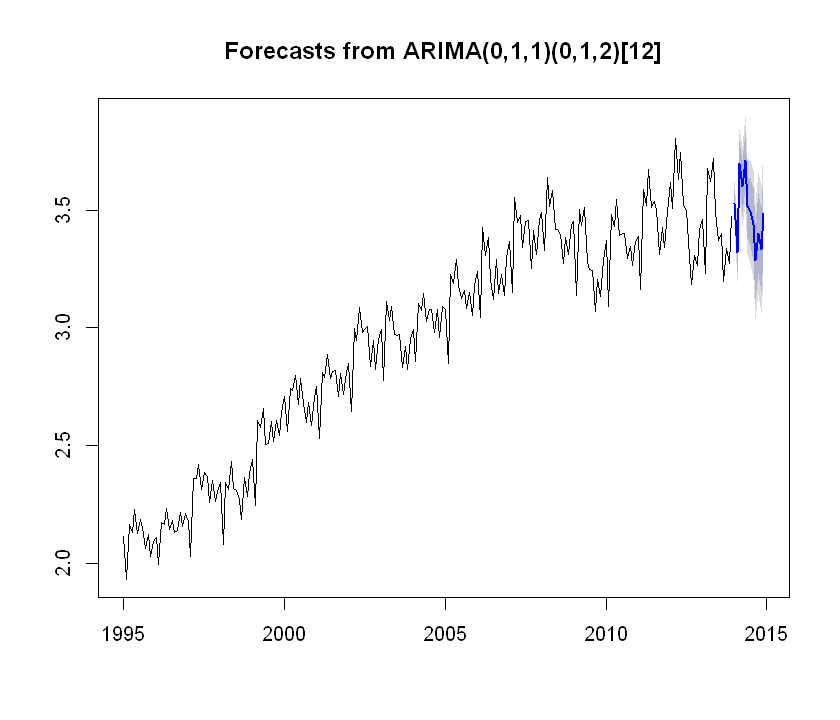

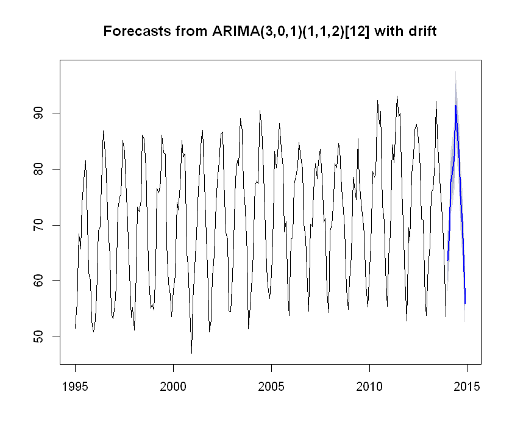

```r
#Use forecast to find the optimal seasonal ARIMA Model for Milk
require(forecast)
Milkfit.elect = auto.arima(CADairy.ts[, 'Milk.ts'], max.p=3, max.q=3,
                       max.P=2, max.Q=2, max.order=5, max.d=2, max.D=1,
                       start.p=0, start.q=0, start.P=0, start.Q=0)
summary(Milkfit.elect)

## Make Milk forecast for 2014
Milkelect.forecast = forecast(Milkfit.elect, h=12)
summary(Milkelect.forecast)
plot(Milkelect.forecast)

#Use forecast to find the optimal seasonal ARIMA Model for Ice cream
Icecreamfit.elect = auto.arima(CADairy.ts[, 'Ice.ts'], max.p=3, max.q=3,
                           max.P=2, max.Q=2, max.order=5, max.d=2, max.D=1,
                           start.p=0, start.q=0, start.P=0, start.Q=0)
summary(Icecreamfit.elect)

## Make Icecream forecast for 2014
Icecreamelect.forecast = forecast(Icecreamfit.elect, h=12)
summary(Icecreamelect.forecast)
plot(Icecreamelect.forecast)
```

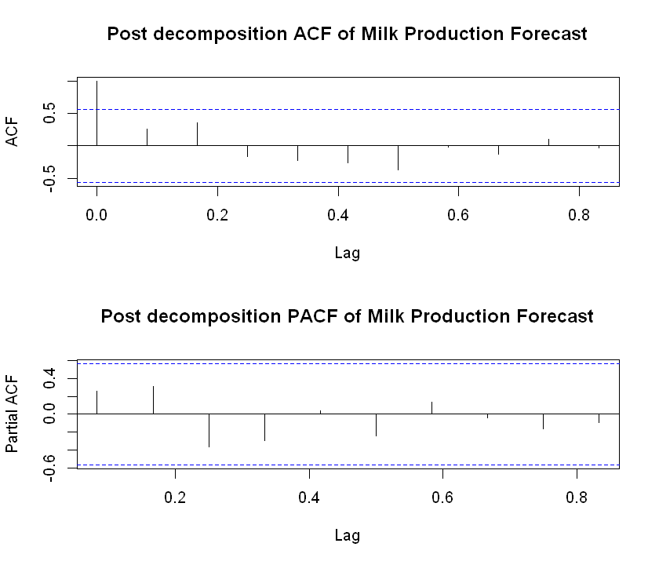

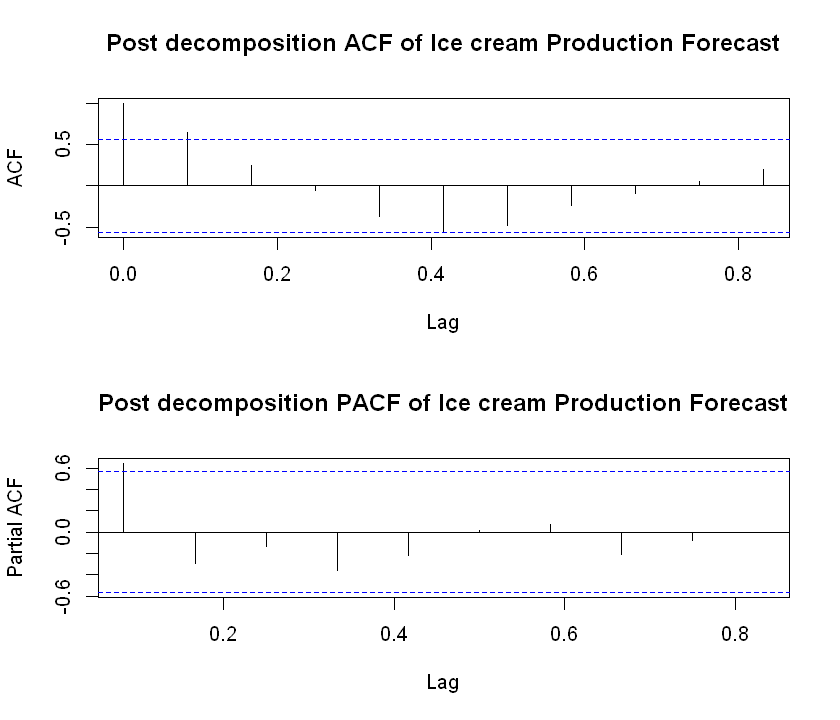

```r
plot.acf(Milkelect.forecast$mean, 'Milk Production Forecast',is.df = FALSE,decomp=TRUE)
plot.acf(Icecreamelect.forecast$mean,'Ice cream Production Forecast',is.df = FALSE,decomp=TRUE)
```